# Assignment_1_water

**Assignment 1 : water**

1. The event can’t have an impact on commercial water transport.

Commerial water transport is limited to the route between the North Sea Canal and Ijsselmeer lake, passing by the north side of the Central Station, leaving the waterways south of the station available for the event without disrupting the commercial water transport.source: https://geo.rijkswaterstaat.nl/arcgis/rest/services/GDR/clearways_scheepvaart/MapServer

1. It would be appreciated if the event also has small impact on the routes of the canal boats.

According to this source, which gives the crowdiness on waterways in Amsterdam, our route has a minor effect on the passanger canal boats, as it evades most busy intersections and waterways. source: https://openresearch.amsterdam/nl/page/92981/grachtenmonitor-2022

1. What is the pollution level of the canals and is there data from all the canals? You can swim next to the AMS but the water there is heavily monitored, is this the same for the rest of Amsterdam?

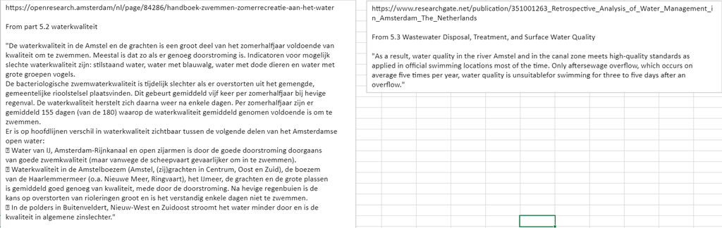

1. Think of a few data sets that are of use for giving a proper advice to the municipality.

Data from several parameters in the 2020 jaarboek on water quality in surface water is stored numerically in excel.

1. If you have geo spatial data, can you figure out how the data is geometrically represented (points, lines, surfaces, hyper planes)?

Some of the geo spatial data, from private boats as well as passenger boats is indicated in points that represent sites that are visited. Other maps represent points where crowdiness was observed. Geo spatial data on commercial water transport is presented as lines.

1. If it is temporal data, what is the interval?

It is not

1. Dataset printed if possible?

```python
import pandas as pd
%matplotlib inline
import numpy as np
import matplotlib.pyplot as plt
```

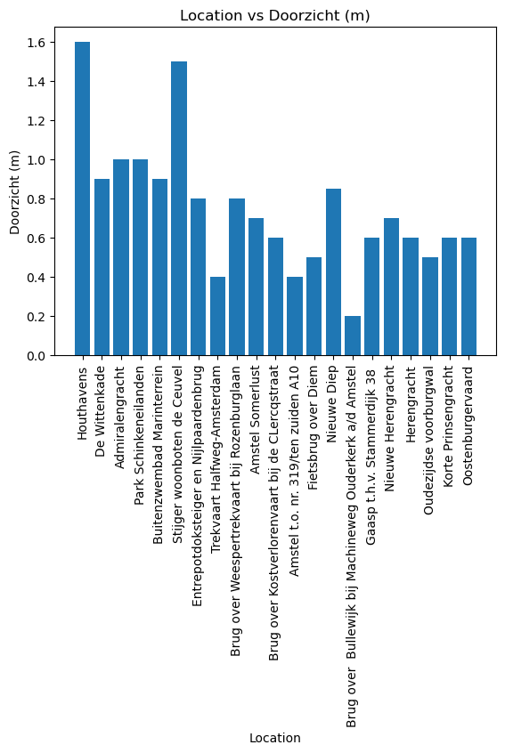

```python
file = pd.read_excel('waterkwaliteit_data.xlsx', skiprows=3, index_col=0, dtype=str)


file[file.columns[0]] = pd.to_numeric(file[file.columns[0]])
file = file.sort_values(by=file.columns[1])


plt.bar(file.index, file[file.columns[0]])



plt.xlabel('Location')
plt.ylabel('Doorzicht (m)')
plt.title('Location vs Doorzicht (m)')
plt.xticks(rotation=90)
plt.show()
```